# Table of Contents

```python
%matplotlib inline
from IPython.display import display, display_markdown

import subprocess as sp
import numpy as np
import pandas as pd
import seaborn as sns
import pymc3 as pm
import arviz as az
import bambi
import copy
import warnings

import matplotlib.pyplot as plt
plt.rcParams['figure.figsize'] = [10, 8]
plt.rcParams['figure.dpi'] = 300

from scipy.stats import pearsonr, spearmanr
from itertools import chain
from collections import Counter

from subs2vec.utensils import log_timer
from subs2vec.vecs import Vectors
from subs2vec.neighbors import compute_nn

def display_md(md, **kwargs):
    return display_markdown(md, raw=True, **kwargs)

def convert_notebook(title, output='html'):
    convert = sp.run(f'jupyter nbconvert {title}.ipynb --to {output} --output {title}.{output}'.split(' '))
    if convert.returncode == 0:
        display_md(f'Jupyter notebook `{title}` converted successfully.')
    else:
        display_md(f'Error: encountered problem converting Jupyter notebook `{title}`')

def download(fname):
    dl = sp.run(f'wget {fname}'.split(' '))
    if dl.returncode == 0:
        display_md(f'Download of `{fname}` succesful.')
    else:
        display_md(f'Download of `{fname}` failed.')

@log_timer
def filter_vecs(vecs, filter_words):
    filtered_vecs = copy.deepcopy(vecs)
    filtered_vecs.vectors = filtered_vecs.vectors[np.isin(filtered_vecs.words, filter_words)]
    filtered_vecs.words = filtered_vecs.words[np.isin(filtered_vecs.words, filter_words)]
    filtered_vecs.n = len(filtered_vecs.words)
    display_md(f'Filtered {vecs.n} vectors, {filtered_vecs.n} remaining.')
    return filtered_vecs

def norm(x):
    return x / np.linalg.norm(x, 2)

sns.set(style='whitegrid')
pd.options.mode.chained_assignment = None
```

# Loading and preparing data

## Loading original participant data (NZ)

```python
df = pd.read_csv('color_semantics_ratings.tsv', sep='\t')
display(df)
```

|  | participant | white | red | orange | yellow | green | blue | purple | brown | black | dimension | group | pp_id |
| --- | --- | --- | --- | --- | --- | --- | --- | --- | --- | --- | --- | --- | --- |
| 0 | 1 | 1 | 7 | 7 | 5 | 1 | 1 | 1 | 3 | 7 | cold-hot | sighted | sighted_1 |
| 1 | 1 | 7 | 1 | 4 | 2 | 3 | 3 | 6 | 6 | 7 | ripe-unripe | sighted | sighted_1 |
| 2 | 1 | 1 | 5 | 6 | 7 | 4 | 2 | 3 | 7 | 6 | new-old | sighted | sighted_1 |
| 3 | 1 | 1 | 7 | 2 | 1 | 4 | 2 | 3 | 5 | 7 | submissive-aggressive | sighted | sighted_1 |
| 4 | 1 | 1 | 7 | 6 | 1 | 2 | 2 | 5 | 3 | 5 | selfless-jealous | sighted | sighted_1 |
| ... | ... | ... | ... | ... | ... | ... | ... | ... | ... | ... | ... | ... | ... |
| 539 | 12 | 1 | 2 | 1 | 2 | 2 | 3 | 2 | 3 | 4 | soft-hard | blind | blind_12 |
| 540 | 12 | 4 | 3 | 3 | 4 | 2 | 2 | 3 | 2 | 5 | light-heavy | blind | blind_12 |
| 541 | 12 | 2 | 4 | 2 | 1 | 2 | 1 | 2 | 3 | 2 | relaxed-tense | blind | blind_12 |
| 542 | 12 | 4 | 2 | 1 | 1 | 1 | 3 | 2 | 3 | 5 | alive-dead | blind | blind_12 |
| 543 | 12 | 6 | 7 | 4 | 3 | 4 | 4 | 1 | 2 | 5 | fast-slow | blind | blind_12 |

544 rows × 13 columns

### Melt dataframe to long format

```python
# these are the colors in the data
colors = ['white', 'red', 'orange', 'yellow', 'green', 'blue', 'purple', 'brown', 'black']

# melt
df_orig = df.melt(
    id_vars=['group', 'dimension', 'pp_id'],
    value_vars=colors,
    var_name='color',
    value_name='rating',
)

# pull out dimension words
dimension_labels = df_orig['dimension'].unique()
dimension_pairs = [pair.split('-') for pair in dimension_labels]
dimensions = list(chain(*dimension_pairs))

# add experiment and self vs. other variables for when we add the replication experiment later
df_orig['experiment'] = 'original'
df_orig['self_vs_other'] = 'self'

display(df_orig)
```

|  | group | dimension | pp_id | color | rating | experiment | self_vs_other |
| --- | --- | --- | --- | --- | --- | --- | --- |
| 0 | sighted | cold-hot | sighted_1 | white | 1 | original | self |
| 1 | sighted | ripe-unripe | sighted_1 | white | 7 | original | self |
| 2 | sighted | new-old | sighted_1 | white | 1 | original | self |
| 3 | sighted | submissive-aggressive | sighted_1 | white | 1 | original | self |
| 4 | sighted | selfless-jealous | sighted_1 | white | 1 | original | self |
| ... | ... | ... | ... | ... | ... | ... | ... |
| 4891 | blind | soft-hard | blind_12 | black | 4 | original | self |
| 4892 | blind | light-heavy | blind_12 | black | 5 | original | self |
| 4893 | blind | relaxed-tense | blind_12 | black | 2 | original | self |
| 4894 | blind | alive-dead | blind_12 | black | 5 | original | self |
| 4895 | blind | fast-slow | blind_12 | black | 5 | original | self |

4896 rows × 7 columns

## Loading replication participant data (US)

```python
df_rep = pd.read_csv('replication_subj_pool.csv')

# little bit of data munging, drop test participant and catch trials
df_rep = df_rep[(df_rep['pp_id'] != 3) & (df_rep['question_type'] != 'catch')]
df_rep = df_rep.drop(columns=['question_type', 'prompt_pre_1'])

# melt to long format
df_rep = df_rep.melt(
    id_vars=['dimension', 'color', 'pp_id'],
    value_vars=['value', 'others_choice'],
    var_name='self_vs_other',
    value_name='rating',
)

# more data munging
df_rep['pp_id'] = 'sighted_' + df_rep['pp_id'].astype(str)
df_rep['self_vs_other'] = df_rep['self_vs_other'].replace({'value': 'self', 'others_choice': 'other'})
df_rep['group'] = 'sighted'
df_rep['experiment'] = 'replication_1'

# there is a weird typo in one of the dimensions (?), so let's correct that here as well
df_rep['dimension'] = df_rep['dimension'].replace({'like-dis...like': 'like-dislike'})

display(df_rep)
```

|  | dimension | color | pp_id | self_vs_other | rating | group | experiment |
| --- | --- | --- | --- | --- | --- | --- | --- |
| 0 | clean-dirty | yellow | sighted_69819 | self | 5 | sighted | replication_1 |
| 1 | soft-hard | yellow | sighted_69819 | self | 2 | sighted | replication_1 |
| 2 | ripe-unripe | yellow | sighted_69819 | self | 1 | sighted | replication_1 |
| 3 | selfless-jealous | yellow | sighted_69819 | self | 5 | sighted | replication_1 |
| 4 | high-low | yellow | sighted_69819 | self | 1 | sighted | replication_1 |
| ... | ... | ... | ... | ... | ... | ... | ... |
| 9567 | like-dislike | orange | sighted_69785 | other | 4 | sighted | replication_1 |
| 9568 | new-old | orange | sighted_69785 | other | 4 | sighted | replication_1 |
| 9569 | clean-dirty | orange | sighted_69785 | other | 5 | sighted | replication_1 |
| 9570 | relaxed-tense | orange | sighted_69785 | other | 5 | sighted | replication_1 |
| 9571 | active-passive | orange | sighted_69785 | other | 3 | sighted | replication_1 |

9572 rows × 7 columns

## Loading 2nd replication data (US, with reading measures)

```python
df_read = pd.read_csv('semantic_diff_with_readmeasure.csv').drop(columns=['Unnamed: 0', 'X'])

display(df_read.groupby('subj_id').mean())
```

| subj_id | value | others_choice | art | fiction | nonfiction | Q9_1 | Q9_2 | Q9_3 | Q9_4 | Q9_5 | ... | Q9_17 | Q9_18 | Q9_19 | Q9_20 | Q9_21 | composite_read | upper_art | upper_fiction | upper_nonfiction | upper_read_motivation |
| --- | --- | --- | --- | --- | --- | --- | --- | --- | --- | --- | --- | --- | --- | --- | --- | --- | --- | --- | --- | --- | --- |
| 67590 | 3.518519 | 3.450617 | 18.0 | 1.0 | 3.0 | 0.0 | 2.0 | 0.0 | 1.0 | 1.0 | ... | -1.0 | 2.0 | 1.0 | 1.0 | 1.0 | 0.722222 | 1.0 | 1.0 | 1.0 | 1.0 |
| 67597 | 3.895062 | 3.820988 | 10.0 | 0.0 | 0.0 | 0.0 | -1.0 | -1.0 | -2.0 | -1.0 | ... | -1.0 | 1.0 | 1.0 | 1.0 | 0.0 | -0.555556 | 1.0 | 0.0 | 0.0 | 0.0 |
| 67648 | 4.129630 | 3.913580 | 9.0 | 0.0 | 1.0 | 0.0 | 0.0 | 0.0 | 0.0 | 0.0 | ... | 0.0 | 0.0 | 0.0 | 0.0 | 0.0 | 0.000000 | 1.0 | 0.0 | 1.0 | 1.0 |
| 67653 | 3.962963 | 3.925926 | 10.0 | 4.0 | 3.0 | 1.0 | 1.0 | 0.0 | 0.0 | 0.0 | ... | 0.0 | 1.0 | -1.0 | 0.0 | 0.0 | -0.222222 | 1.0 | 1.0 | 1.0 | 0.0 |
| 67656 | 3.469136 | 3.654321 | 7.0 | 0.0 | 0.0 | 1.0 | -2.0 | -2.0 | -2.0 | -2.0 | ... | 0.0 | 2.0 | 0.0 | 0.0 | -2.0 | -1.333333 | 1.0 | 0.0 | 0.0 | 0.0 |
| ... | ... | ... | ... | ... | ... | ... | ... | ... | ... | ... | ... | ... | ... | ... | ... | ... | ... | ... | ... | ... | ... |
| 69841 | 3.432099 | 3.518519 | 6.0 | 1.0 | 3.0 | 1.0 | 0.0 | -2.0 | -2.0 | -1.0 | ... | 1.0 | -1.0 | 1.0 | 2.0 | 0.0 | -0.722222 | 0.0 | 1.0 | 1.0 | 0.0 |
| 69860 | 3.716049 | 3.796296 | 21.0 | 0.0 | 1.0 | -1.0 | 1.0 | -1.0 | 1.0 | 1.0 | ... | 0.0 | -2.0 | 1.0 | 1.0 | 1.0 | 0.222222 | 1.0 | 0.0 | 1.0 | 1.0 |
| 69889 | 3.932099 | 4.000000 | 6.0 | 0.0 | 1.0 | 1.0 | 1.0 | -2.0 | -2.0 | -1.0 | ... | 0.0 | -1.0 | 0.0 | 0.0 | -1.0 | -0.888889 | 0.0 | 0.0 | 1.0 | 0.0 |
| 69914 | 4.037037 | 3.907407 | 26.0 | 2.0 | 4.0 | 2.0 | 1.0 | -1.0 | 2.0 | 2.0 | ... | -2.0 | 1.0 | 1.0 | 1.0 | -1.0 | 0.277778 | 1.0 | 1.0 | 1.0 | 1.0 |
| 70147 | 3.197531 | 3.450617 | 12.0 | 1.0 | 0.0 | 1.0 | 1.0 | -1.0 | 1.0 | 0.0 | ... | 1.0 | 0.0 | 1.0 | -1.0 | 1.0 | 0.111111 | 1.0 | 1.0 | 0.0 | 1.0 |

88 rows × 31 columns

### Compute reading subscales

```python
df_read['reading_motivation'] = df_read.apply(
    lambda x: (0
    + x['Q9_1']
    + x['Q9_2']
    + x['Q9_3']
    + x['Q9_4']
    + x['Q9_5']
    + x['Q9_6']
    + x['Q9_7']
    + x['Q9_8']
    + x['Q9_9']
    + x['Q9_10']
    + x['Q9_11']
    + x['Q9_12']
    + x['Q9_13']
    + x['Q9_14'] * -1
    + x['Q9_15']
    + x['Q9_16']
    + x['Q9_17'] * -1
    + x['Q9_18']
    + x['Q9_19']
    + x['Q9_20']
    + x['Q9_21']) / 21,
axis=1)

df_read['reading_part_of_self'] = df_read.apply(
    lambda x: (0
    + x['Q9_2']
    + x['Q9_3']
    + x['Q9_4']
    + x['Q9_5']
    + x['Q9_6']
    + x['Q9_9']
    + x['Q9_10']
    + x['Q9_11']) / 8,
axis=1)

df_read['reading_efficacy'] = df_read.apply(
    lambda x: (0
    + x['Q9_1']
    + x['Q9_14'] * -1
    + x['Q9_16']
    + x['Q9_17'] * -1
    + x['Q9_19']
    + x['Q9_20']) / 6,
axis=1)

df_read['reading_recognition'] = df_read.apply(
    lambda x: (0
    + x['Q9_12']
    + x['Q9_13']
    + x['Q9_15']) / 3,
axis=1)

df_read['reading_other_realms'] = df_read.apply(
    lambda x: (0
    + x['Q9_7']
    + x['Q9_8']
    + x['Q9_18']
    + x['Q9_21']) / 4,
axis=1)
```

```python
# rename participant id column to match earlier datasets
df_read = df_read.rename(columns={'subj_id': 'pp_id'})

# melt to long format
df_read = df_read.melt(
    id_vars=['dimension', 'color', 'pp_id', 'art', 'fiction', 'nonfiction', 'reading_motivation',
             'reading_part_of_self', 'reading_efficacy', 'reading_recognition', 'reading_other_realms'],
    value_vars=['value', 'others_choice'],
    var_name='self_vs_other',
    value_name='rating',
)

# more data munging
df_read['pp_id'] = 'sighted_' + df_read['pp_id'].astype(str)
df_read['self_vs_other'] = df_read['self_vs_other'].replace({'value': 'self', 'others_choice': 'other'})
df_read['group'] = 'sighted'
df_read['experiment'] = 'replication_2'

display(df_read)
```

|  | dimension | color | pp_id | art | fiction | nonfiction | reading_motivation | reading_part_of_self | reading_efficacy | reading_recognition | reading_other_realms | self_vs_other | rating | group | experiment |
| --- | --- | --- | --- | --- | --- | --- | --- | --- | --- | --- | --- | --- | --- | --- | --- |
| 0 | cold-hot | brown | sighted_69212 | 3.0 | 0.0 | 1.0 | 1.619048 | 2.000 | 0.666667 | 2.0 | 2.00 | self | 4 | sighted | replication_2 |
| 1 | ripe-unripe | brown | sighted_69212 | 3.0 | 0.0 | 1.0 | 1.619048 | 2.000 | 0.666667 | 2.0 | 2.00 | self | 7 | sighted | replication_2 |
| 2 | new-old | brown | sighted_69212 | 3.0 | 0.0 | 1.0 | 1.619048 | 2.000 | 0.666667 | 2.0 | 2.00 | self | 6 | sighted | replication_2 |
| 3 | submissive-aggressive | brown | sighted_69212 | 3.0 | 0.0 | 1.0 | 1.619048 | 2.000 | 0.666667 | 2.0 | 2.00 | self | 2 | sighted | replication_2 |
| 4 | selfless-jealous | brown | sighted_69212 | 3.0 | 0.0 | 1.0 | 1.619048 | 2.000 | 0.666667 | 2.0 | 2.00 | self | 5 | sighted | replication_2 |
| ... | ... | ... | ... | ... | ... | ... | ... | ... | ... | ... | ... | ... | ... | ... | ... |
| 28507 | light-heavy | red | sighted_68129 | 11.0 | 0.0 | 1.0 | -0.571429 | -0.375 | -0.833333 | -1.0 | -0.25 | other | 5 | sighted | replication_2 |
| 28508 | relaxed-tense | red | sighted_68129 | 11.0 | 0.0 | 1.0 | -0.571429 | -0.375 | -0.833333 | -1.0 | -0.25 | other | 5 | sighted | replication_2 |
| 28509 | alive-dead | red | sighted_68129 | 11.0 | 0.0 | 1.0 | -0.571429 | -0.375 | -0.833333 | -1.0 | -0.25 | other | 6 | sighted | replication_2 |
| 28510 | fast-slow | red | sighted_68129 | 11.0 | 0.0 | 1.0 | -0.571429 | -0.375 | -0.833333 | -1.0 | -0.25 | other | 3 | sighted | replication_2 |
| 28511 | high-low | red | sighted_68129 | 11.0 | 0.0 | 1.0 | -0.571429 | -0.375 | -0.833333 | -1.0 | -0.25 | other | 2 | sighted | replication_2 |

28512 rows × 15 columns

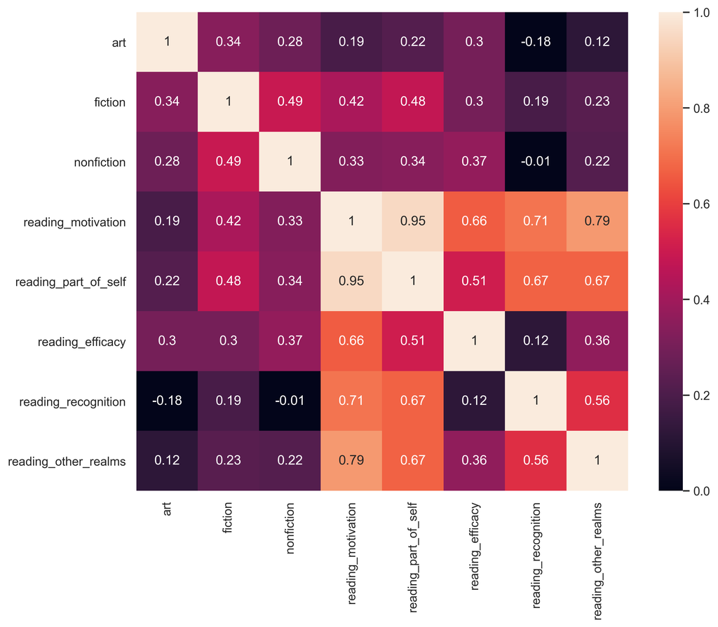

```python
corrs = df_read[['art', 'fiction', 'nonfiction', 'reading_motivation', 'reading_part_of_self',
                 'reading_efficacy', 'reading_recognition', 'reading_other_realms']].corr().round(2)
g = sns.heatmap(corrs, vmin=0, vmax=1, annot=True)
g.set_yticklabels(g.get_yticklabels(), rotation=0);
```

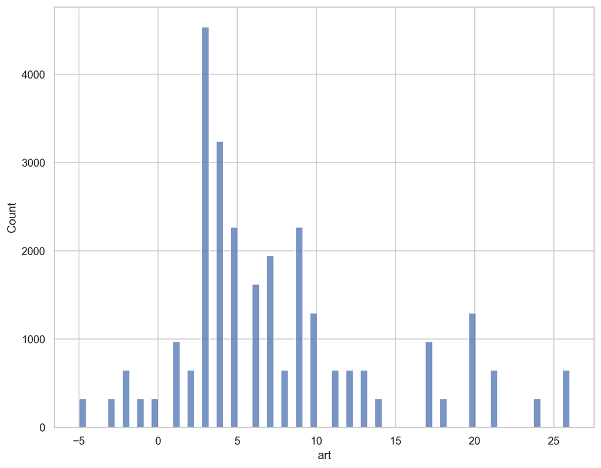

```python
g = sns.histplot(x='art', data=df_read)
```

## Retrieving vectors for words and dimension word pairs

```python
vecs = Vectors('../embeddings/cc.en.300.vec', n=2e5, d=300, normalize=True)
vecs = filter_vecs(vecs, np.array(colors + dimensions))
vecs_dict = vecs.as_dict()

color_vecs = filter_vecs(vecs, np.array(colors))
dimension_vecs = filter_vecs(vecs, np.array(dimensions))

dimension_pair_vecs = np.vstack([vecs_dict[pair[0]] - vecs_dict[pair[1]] for pair in dimension_pairs])
```

```
[INFO] loading vectors ../embeddings/cc.en.300.vec
[INFO] <function Vectors.__init__ at 0x7f991a2a3840> ran in 13.907 seconds
```

Filtered 200000 vectors, 43 remaining.

```
[INFO] <function filter_vecs at 0x7f991a697bf8> ran in 0.747 seconds
[INFO] <function Vectors.as_dict at 0x7f991a2a3a60> ran in 0.000 seconds
```

Filtered 43 vectors, 9 remaining.

```
[INFO] <function filter_vecs at 0x7f991a697bf8> ran in 0.002 seconds
```

Filtered 43 vectors, 34 remaining.

```
[INFO] <function filter_vecs at 0x7f991a697bf8> ran in 0.002 seconds
```

# Ranking color-semantic associations in word embeddings

## Using single dimension words

```python
dimension_neighbors = compute_nn(color_vecs, dimension_vecs.vectors, dimension_vecs.words, num_neighbors=9, whole_matrix=True)
dimension_neighbors = dimension_neighbors.drop(columns=[
    'neighbor -1',
    'neighbor -2',
    'neighbor -3',
    'neighbor -4',
    'neighbor -5',
    'neighbor -6',
    'neighbor -7',
    'neighbor -8',
    'neighbor -9'
]).rename(columns={'target': 'dimension'})
display(dimension_neighbors)
```

```
[INFO] <function Vectors.as_dict at 0x7f991a2a3a60> ran in 0.000 seconds
[INFO] computing analogies using whole matrix additive method
[INFO] <function compute_nn at 0x7f991a2a36a8> ran in 0.005 seconds
```

|  | dimension | neighbor 0 | neighbor 1 | neighbor 2 | neighbor 3 | neighbor 4 | neighbor 5 | neighbor 6 | neighbor 7 | neighbor 8 |
| --- | --- | --- | --- | --- | --- | --- | --- | --- | --- | --- |
| 0 | like | blue | purple | black | orange | white | red | brown | yellow | green |
| 1 | new | green | blue | red | orange | purple | black | yellow | white | brown |
| 2 | old | white | brown | black | yellow | red | orange | blue | green | purple |
| 3 | hard | white | black | red | blue | yellow | green | purple | brown | orange |
| 4 | light | blue | red | brown | green | yellow | orange | purple | white | black |
| 5 | happy | blue | green | purple | orange | white | yellow | brown | red | black |
| 6 | clean | green | white | blue | black | brown | red | orange | yellow | purple |
| 7 | hot | red | brown | blue | black | orange | white | purple | yellow | green |
| 8 | fast | green | red | brown | blue | purple | orange | yellow | black | white |
| 9 | active | orange | green | black | blue | red | white | yellow | purple | brown |
| 10 | fresh | green | orange | red | white | blue | yellow | black | purple | brown |
| 11 | cold | blue | red | brown | white | yellow | orange | purple | green | black |
| 12 | dead | black | red | white | brown | blue | orange | yellow | green | purple |
| 13 | heavy | brown | red | black | purple | blue | yellow | white | green | orange |
| 14 | soft | brown | white | blue | green | yellow | red | purple | black | orange |
| 15 | slow | brown | green | red | yellow | orange | purple | blue | black | white |
| 16 | exciting | orange | green | purple | blue | red | yellow | brown | black | white |
| 17 | sad | purple | blue | orange | yellow | brown | red | white | black | green |
| 18 | alive | black | green | red | blue | orange | white | yellow | purple | brown |
| 19 | angry | black | red | white | purple | orange | blue | yellow | brown | green |
| 20 | dirty | brown | white | black | red | purple | blue | green | yellow | orange |
| 21 | calm | blue | white | green | orange | brown | red | purple | yellow | black |
| 22 | aggressive | orange | yellow | red | black | green | white | blue | purple | brown |
| 23 | relaxed | green | blue | brown | white | black | red | purple | orange | yellow |
| 24 | passive | green | black | white | blue | yellow | red | brown | purple | orange |
| 25 | jealous | purple | white | blue | orange | black | yellow | brown | red | green |
| 26 | dull | brown | yellow | blue | purple | green | white | black | red | orange |
| 27 | dislike | purple | orange | white | black | yellow | brown | green | blue | red |
| 28 | tense | red | blue | purple | yellow | orange | brown | white | green | black |
| 29 | ripe | orange | red | yellow | green | purple | brown | white | black | blue |
| 30 | stale | brown | orange | yellow | red | white | green | black | purple | blue |
| 31 | submissive | white | black | brown | blue | purple | red | yellow | green | orange |
| 32 | selfless | green | purple | blue | orange | white | black | yellow | red | brown |
| 33 | unripe | green | yellow | orange | purple | red | brown | white | blue | black |

## Using dimension axes (word pair contrasts), with nearest neighbor (cosine) method

```python
dimension_neighbors = compute_nn(color_vecs, dimension_pair_vecs, np.array(dimension_labels), num_neighbors=9, whole_matrix=True)
dimension_neighbors = dimension_neighbors.drop(columns=[
    'neighbor -1',
    'neighbor -2',
    'neighbor -3',
    'neighbor -4',
    'neighbor -5',
    'neighbor -6',
    'neighbor -7',
    'neighbor -8',
    'neighbor -9'
]).rename(columns={'target': 'dimension'})
display(dimension_neighbors)
```

```
[INFO] <function Vectors.as_dict at 0x7f991a2a3a60> ran in 0.000 seconds
[INFO] computing analogies using whole matrix additive method
[INFO] <function compute_nn at 0x7f991a2a36a8> ran in 0.005 seconds
```

|  | dimension | neighbor 0 | neighbor 1 | neighbor 2 | neighbor 3 | neighbor 4 | neighbor 5 | neighbor 6 | neighbor 7 | neighbor 8 |
| --- | --- | --- | --- | --- | --- | --- | --- | --- | --- | --- |
| 0 | cold-hot | blue | white | yellow | green | orange | purple | brown | red | black |
| 1 | ripe-unripe | black | red | white | brown | blue | purple | orange | yellow | green |
| 2 | new-old | green | purple | blue | orange | red | yellow | black | white | brown |
| 3 | submissive-aggressive | brown | white | black | purple | blue | red | yellow | green | orange |
| 4 | selfless-jealous | green | blue | orange | yellow | red | black | white | brown | purple |
| 5 | active-passive | orange | blue | red | purple | brown | green | black | yellow | white |
| 6 | like-dislike | blue | red | black | brown | white | yellow | green | orange | purple |
| 7 | clean-dirty | green | orange | blue | white | yellow | black | red | purple | brown |
| 8 | fresh-stale | green | blue | white | red | orange | black | purple | yellow | brown |
| 9 | calm-angry | green | blue | brown | white | orange | yellow | purple | red | black |
| 10 | happy-sad | green | white | blue | orange | purple | red | black | yellow | brown |
| 11 | exciting-dull | orange | green | purple | red | blue | black | yellow | white | brown |
| 12 | soft-hard | brown | green | purple | blue | yellow | white | red | orange | black |
| 13 | light-heavy | green | orange | blue | yellow | red | white | purple | brown | black |
| 14 | relaxed-tense | green | white | brown | blue | black | orange | purple | yellow | red |
| 15 | alive-dead | green | orange | purple | blue | yellow | white | red | black | brown |
| 16 | fast-slow | green | blue | purple | white | red | black | orange | yellow | brown |

# Creating datasets for statistical models

## Merging data and predictors

### Merge data

```python
df_joint = pd.concat([df_orig, df_rep, df_read]).reset_index()
display(df_joint)
```

|  | index | group | dimension | pp_id | color | rating | experiment | self_vs_other | art | fiction | nonfiction | reading_motivation | reading_part_of_self | reading_efficacy | reading_recognition | reading_other_realms |
| --- | --- | --- | --- | --- | --- | --- | --- | --- | --- | --- | --- | --- | --- | --- | --- | --- |
| 0 | 0 | sighted | cold-hot | sighted_1 | white | 1 | original | self | NaN | NaN | NaN | NaN | NaN | NaN | NaN | NaN |
| 1 | 1 | sighted | ripe-unripe | sighted_1 | white | 7 | original | self | NaN | NaN | NaN | NaN | NaN | NaN | NaN | NaN |
| 2 | 2 | sighted | new-old | sighted_1 | white | 1 | original | self | NaN | NaN | NaN | NaN | NaN | NaN | NaN | NaN |
| 3 | 3 | sighted | submissive-aggressive | sighted_1 | white | 1 | original | self | NaN | NaN | NaN | NaN | NaN | NaN | NaN | NaN |
| 4 | 4 | sighted | selfless-jealous | sighted_1 | white | 1 | original | self | NaN | NaN | NaN | NaN | NaN | NaN | NaN | NaN |
| ... | ... | ... | ... | ... | ... | ... | ... | ... | ... | ... | ... | ... | ... | ... | ... | ... |
| 42975 | 28507 | sighted | light-heavy | sighted_68129 | red | 5 | replication_2 | other | 11.0 | 0.0 | 1.0 | -0.571429 | -0.375 | -0.833333 | -1.0 | -0.25 |
| 42976 | 28508 | sighted | relaxed-tense | sighted_68129 | red | 5 | replication_2 | other | 11.0 | 0.0 | 1.0 | -0.571429 | -0.375 | -0.833333 | -1.0 | -0.25 |
| 42977 | 28509 | sighted | alive-dead | sighted_68129 | red | 6 | replication_2 | other | 11.0 | 0.0 | 1.0 | -0.571429 | -0.375 | -0.833333 | -1.0 | -0.25 |
| 42978 | 28510 | sighted | fast-slow | sighted_68129 | red | 3 | replication_2 | other | 11.0 | 0.0 | 1.0 | -0.571429 | -0.375 | -0.833333 | -1.0 | -0.25 |
| 42979 | 28511 | sighted | high-low | sighted_68129 | red | 2 | replication_2 | other | 11.0 | 0.0 | 1.0 | -0.571429 | -0.375 | -0.833333 | -1.0 | -0.25 |

42980 rows × 16 columns

### Add word frequency (Van Paridon & Thompson, 2020)

```python
freqs = pd.read_csv('../embeddings/dedup.en.words.unigrams.tsv', sep='\t')
freqs['log_freq'] = np.log(freqs['unigram_freq'])
freqs = freqs.drop(columns='unigram_freq')
display(freqs.round(2))
```

|  | unigram | log_freq |
| --- | --- | --- |
| 0 | the | 17.10 |
| 1 | you | 17.06 |
| 2 | i | 17.04 |
| 3 | to | 16.78 |
| 4 | a | 16.59 |
| ... | ... | ... |
| 2397976 | tpar1 | 0.00 |
| 2397977 | giacoia | 0.00 |
| 2397978 | ourcinders | 0.00 |
| 2397979 | tourret | 0.00 |
| 2397980 | iroki | 0.00 |

2397981 rows × 2 columns

```python
df_joint['word1'] = df_joint['dimension'].apply(lambda x: x.split('-')[0])
df_joint['word2'] = df_joint['dimension'].apply(lambda x: x.split('-')[1])
df_joint = df_joint.merge(freqs, left_on='word1', right_on='unigram', how='left')
df_joint = df_joint.merge(freqs, left_on='word2', right_on='unigram', how='left')
df_joint['frequency'] = df_joint['log_freq_x'] - df_joint['log_freq_y']
df_joint = df_joint.drop(columns=[
    'unigram_x',
    'unigram_y',
    'log_freq_x',
    'log_freq_y'
])
display(df_joint.round(2))
```

|  | index | group | dimension | pp_id | color | rating | experiment | self_vs_other | art | fiction | nonfiction | reading_motivation | reading_part_of_self | reading_efficacy | reading_recognition | reading_other_realms | word1 | word2 | frequency |
| --- | --- | --- | --- | --- | --- | --- | --- | --- | --- | --- | --- | --- | --- | --- | --- | --- | --- | --- | --- |
| 0 | 0 | sighted | cold-hot | sighted_1 | white | 1 | original | self | NaN | NaN | NaN | NaN | NaN | NaN | NaN | NaN | cold | hot | -0.22 |
| 1 | 1 | sighted | ripe-unripe | sighted_1 | white | 7 | original | self | NaN | NaN | NaN | NaN | NaN | NaN | NaN | NaN | ripe | unripe | 3.49 |
| 2 | 2 | sighted | new-old | sighted_1 | white | 1 | original | self | NaN | NaN | NaN | NaN | NaN | NaN | NaN | NaN | new | old | 0.12 |
| 3 | 3 | sighted | submissive-aggressive | sighted_1 | white | 1 | original | self | NaN | NaN | NaN | NaN | NaN | NaN | NaN | NaN | submissive | aggressive | -2.35 |
| 4 | 4 | sighted | selfless-jealous | sighted_1 | white | 1 | original | self | NaN | NaN | NaN | NaN | NaN | NaN | NaN | NaN | selfless | jealous | -2.96 |
| ... | ... | ... | ... | ... | ... | ... | ... | ... | ... | ... | ... | ... | ... | ... | ... | ... | ... | ... | ... |
| 42975 | 28507 | sighted | light-heavy | sighted_68129 | red | 5 | replication_2 | other | 11.0 | 0.0 | 1.0 | -0.57 | -0.38 | -0.83 | -1.0 | -0.25 | light | heavy | 1.24 |
| 42976 | 28508 | sighted | relaxed-tense | sighted_68129 | red | 5 | replication_2 | other | 11.0 | 0.0 | 1.0 | -0.57 | -0.38 | -0.83 | -1.0 | -0.25 | relaxed | tense | -0.23 |
| 42977 | 28509 | sighted | alive-dead | sighted_68129 | red | 6 | replication_2 | other | 11.0 | 0.0 | 1.0 | -0.57 | -0.38 | -0.83 | -1.0 | -0.25 | alive | dead | -0.90 |
| 42978 | 28510 | sighted | fast-slow | sighted_68129 | red | 3 | replication_2 | other | 11.0 | 0.0 | 1.0 | -0.57 | -0.38 | -0.83 | -1.0 | -0.25 | fast | slow | 0.76 |
| 42979 | 28511 | sighted | high-low | sighted_68129 | red | 2 | replication_2 | other | 11.0 | 0.0 | 1.0 | -0.57 | -0.38 | -0.83 | -1.0 | -0.25 | high | low | 1.24 |

42980 rows × 19 columns

### Add concreteness (Brysbaert et al., 2014)

```python
concreteness = pd.read_csv('../embeddings/en-brysbaert-2014.tsv', sep='\t')
display(concreteness)
```

|  | word | concreteness |
| --- | --- | --- |
| 0 | a | 1.46 |
| 1 | aardvark | 4.68 |
| 2 | aback | 1.65 |
| 3 | abacus | 4.52 |
| 4 | abandon | 2.54 |
| ... | ... | ... |
| 37053 | zoologist | 4.30 |
| 37054 | zoology | 3.37 |
| 37055 | zoom | 3.10 |
| 37056 | zoophobia | 2.04 |
| 37057 | zucchini | 4.87 |

37058 rows × 2 columns

```python
df_joint = df_joint.merge(concreteness, left_on='word1', right_on='word', how='left')
df_joint = df_joint.merge(concreteness, left_on='word2', right_on='word', how='left')
df_joint['concreteness'] = df_joint['concreteness_x'] - df_joint['concreteness_y']
df_joint = df_joint.drop(columns=[
    'word_x',
    'word_y',
    'concreteness_x',
    'concreteness_y'
])
display(df_joint.round(2))
```

|  | index | group | dimension | pp_id | color | rating | experiment | self_vs_other | art | fiction | nonfiction | reading_motivation | reading_part_of_self | reading_efficacy | reading_recognition | reading_other_realms | word1 | word2 | frequency | concreteness |
| --- | --- | --- | --- | --- | --- | --- | --- | --- | --- | --- | --- | --- | --- | --- | --- | --- | --- | --- | --- | --- |
| 0 | 0 | sighted | cold-hot | sighted_1 | white | 1 | original | self | NaN | NaN | NaN | NaN | NaN | NaN | NaN | NaN | cold | hot | -0.22 | -0.46 |
| 1 | 1 | sighted | ripe-unripe | sighted_1 | white | 7 | original | self | NaN | NaN | NaN | NaN | NaN | NaN | NaN | NaN | ripe | unripe | 3.49 | -0.01 |
| 2 | 2 | sighted | new-old | sighted_1 | white | 1 | original | self | NaN | NaN | NaN | NaN | NaN | NaN | NaN | NaN | new | old | 0.12 | 0.09 |
| 3 | 3 | sighted | submissive-aggressive | sighted_1 | white | 1 | original | self | NaN | NaN | NaN | NaN | NaN | NaN | NaN | NaN | submissive | aggressive | -2.35 | -0.82 |
| 4 | 4 | sighted | selfless-jealous | sighted_1 | white | 1 | original | self | NaN | NaN | NaN | NaN | NaN | NaN | NaN | NaN | selfless | jealous | -2.96 | -0.56 |
| ... | ... | ... | ... | ... | ... | ... | ... | ... | ... | ... | ... | ... | ... | ... | ... | ... | ... | ... | ... | ... |
| 42975 | 28507 | sighted | light-heavy | sighted_68129 | red | 5 | replication_2 | other | 11.0 | 0.0 | 1.0 | -0.57 | -0.38 | -0.83 | -1.0 | -0.25 | light | heavy | 1.24 | 0.84 |
| 42976 | 28508 | sighted | relaxed-tense | sighted_68129 | red | 5 | replication_2 | other | 11.0 | 0.0 | 1.0 | -0.57 | -0.38 | -0.83 | -1.0 | -0.25 | relaxed | tense | -0.23 | 0.15 |
| 42977 | 28509 | sighted | alive-dead | sighted_68129 | red | 6 | replication_2 | other | 11.0 | 0.0 | 1.0 | -0.57 | -0.38 | -0.83 | -1.0 | -0.25 | alive | dead | -0.90 | -0.93 |
| 42978 | 28510 | sighted | fast-slow | sighted_68129 | red | 3 | replication_2 | other | 11.0 | 0.0 | 1.0 | -0.57 | -0.38 | -0.83 | -1.0 | -0.25 | fast | slow | 0.76 | 0.04 |
| 42979 | 28511 | sighted | high-low | sighted_68129 | red | 2 | replication_2 | other | 11.0 | 0.0 | 1.0 | -0.57 | -0.38 | -0.83 | -1.0 | -0.25 | high | low | 1.24 | 0.12 |

42980 rows × 20 columns

### Add Small World of Words associations (De Deyne et al., 2018)

```python
swow = pd.read_csv('../embeddings/SWOW-EN.R100.csv')
display(swow)
```

|  | Unnamed: 0 | id | participantID | age | gender | nativeLanguage | country | education | created_at | cue | R1 | R2 | R3 |
| --- | --- | --- | --- | --- | --- | --- | --- | --- | --- | --- | --- | --- | --- |
| 0 | 1 | 29 | 3 | 33 | Fe | United States | Australia | NaN | 2011-08-12 02:19:38 | although | nevertheless | yet | but |
| 1 | 2 | 30 | 3 | 33 | Fe | United States | Australia | NaN | 2011-08-12 02:19:38 | deal | no | cards | shake |
| 2 | 3 | 31 | 3 | 33 | Fe | United States | Australia | NaN | 2011-08-12 02:19:38 | music | notes | band | rhythm |
| 3 | 4 | 32 | 3 | 33 | Fe | United States | Australia | NaN | 2011-08-12 02:19:38 | inform | tell | rat on | NaN |
| 4 | 5 | 33 | 3 | 33 | Fe | United States | Australia | NaN | 2011-08-12 02:19:38 | way | path | via | method |
| ... | ... | ... | ... | ... | ... | ... | ... | ... | ... | ... | ... | ... | ... |
| 1228195 | 1228196 | 1530300 | 132506 | 29 | Ma | Canada | Australia | 5.0 | 2018-08-10 01:56:27 | strange | mask | weird | stranger |
| 1228196 | 1228197 | 1530290 | 132506 | 29 | Ma | Canada | Australia | 5.0 | 2018-08-10 01:56:27 | sunset | sea | sky | clause |
| 1228197 | 1228198 | 1530291 | 132506 | 29 | Ma | Canada | Australia | 5.0 | 2018-08-10 01:56:27 | useless | pitty | worthless | worth |
| 1228198 | 1228199 | 1530284 | 132506 | 29 | Ma | Canada | Australia | 5.0 | 2018-08-10 01:56:27 | volume | loud | music | key |
| 1228199 | 1228200 | 1530288 | 132506 | 29 | Ma | Canada | Australia | 5.0 | 2018-08-10 01:56:27 | whenever | who | where | always |

1228200 rows × 13 columns

```python
def add_swow(df, swow, colname):
    swow = pd.DataFrame(swow.groupby('cue')['resp'].value_counts()).rename(columns={'resp': 'n'})
    swow = swow.reset_index()
    df = df.merge(swow, left_on=['word1', 'color'], right_on=['cue', 'resp'], how='left')
    df = df.merge(swow, left_on=['word2', 'color'], right_on=['cue', 'resp'], how='left')
    df['n_x'] = df['n_x'].fillna(0)
    df['n_y'] = df['n_y'].fillna(0)
    df[colname] = df['n_x'] - df['n_y']
    df = df.drop(columns=[
        'cue_x',
        'cue_y',
        'resp_x',
        'resp_y',
        'n_x',
        'n_y',
    ])
    return df

swow = swow[swow['cue'].isin(dimensions)]
swow_NZ = swow[(swow['country'] == 'New Zealand')]  # select only NZ respondents
swow_US = swow[(swow['country'] == 'United States')]  # select only US respondents

# count only R1 (maximal discounting)
df_joint = add_swow(df_joint, swow.rename(columns={'R1': 'resp'}), 'swow_R1')
df_joint = add_swow(df_joint, swow_NZ.rename(columns={'R1': 'resp'}), 'swow_R1_NZ')  # US
df_joint = add_swow(df_joint, swow_US.rename(columns={'R1': 'resp'}), 'swow_R1_US')  # NZ

# count R1, R2, and R3 with equal weight (minimal discounting)
swow_all = swow.melt(
    id_vars=['id', 'participantID', 'created_at', 'cue'],
    value_vars=['R1', 'R2', 'R3'],
    value_name='resp',
)
df_joint = add_swow(df_joint, swow_all, 'swow_all')

# NZ
swow_all_NZ = swow_NZ.melt(
    id_vars=['id', 'participantID', 'created_at', 'cue'],
    value_vars=['R1', 'R2', 'R3'],
    value_name='resp',
)
df_joint = add_swow(df_joint, swow_all_NZ, 'swow_all_NZ')

# US
swow_all_US = swow_US.melt(
    id_vars=['id', 'participantID', 'created_at', 'cue'],
    value_vars=['R1', 'R2', 'R3'],
    value_name='resp',
)
df_joint = add_swow(df_joint, swow_all_US, 'swow_all_US')

display(df_joint)
```

|  | index | group | dimension | pp_id | color | rating | experiment | self_vs_other | art | fiction | ... | word1 | word2 | frequency | concreteness | swow_R1 | swow_R1_NZ | swow_R1_US | swow_all | swow_all_NZ | swow_all_US |
| --- | --- | --- | --- | --- | --- | --- | --- | --- | --- | --- | --- | --- | --- | --- | --- | --- | --- | --- | --- | --- | --- |
| 0 | 0 | sighted | cold-hot | sighted_1 | white | 1 | original | self | NaN | NaN | ... | cold | hot | -0.216432 | -0.46 | 0.0 | 0.0 | 0.0 | 0.0 | 0.0 | 0.0 |
| 1 | 1 | sighted | ripe-unripe | sighted_1 | white | 7 | original | self | NaN | NaN | ... | ripe | unripe | 3.485549 | -0.01 | 0.0 | 0.0 | 0.0 | 0.0 | 0.0 | 0.0 |
| 2 | 2 | sighted | new-old | sighted_1 | white | 1 | original | self | NaN | NaN | ... | new | old | 0.119068 | 0.09 | 0.0 | 0.0 | 0.0 | 0.0 | 0.0 | 0.0 |
| 3 | 3 | sighted | submissive-aggressive | sighted_1 | white | 1 | original | self | NaN | NaN | ... | submissive | aggressive | -2.352148 | -0.82 | 0.0 | 0.0 | 0.0 | 0.0 | 0.0 | 0.0 |
| 4 | 4 | sighted | selfless-jealous | sighted_1 | white | 1 | original | self | NaN | NaN | ... | selfless | jealous | -2.955968 | -0.56 | 0.0 | 0.0 | 0.0 | 0.0 | 0.0 | 0.0 |
| ... | ... | ... | ... | ... | ... | ... | ... | ... | ... | ... | ... | ... | ... | ... | ... | ... | ... | ... | ... | ... | ... |
| 42975 | 28507 | sighted | light-heavy | sighted_68129 | red | 5 | replication_2 | other | 11.0 | 0.0 | ... | light | heavy | 1.240142 | 0.84 | 0.0 | 0.0 | 0.0 | 0.0 | 0.0 | 0.0 |
| 42976 | 28508 | sighted | relaxed-tense | sighted_68129 | red | 5 | replication_2 | other | 11.0 | 0.0 | ... | relaxed | tense | -0.229652 | 0.15 | 0.0 | 0.0 | 0.0 | 0.0 | 0.0 | 0.0 |
| 42977 | 28509 | sighted | alive-dead | sighted_68129 | red | 6 | replication_2 | other | 11.0 | 0.0 | ... | alive | dead | -0.904786 | -0.93 | -1.0 | 0.0 | 0.0 | -1.0 | 0.0 | 0.0 |
| 42978 | 28510 | sighted | fast-slow | sighted_68129 | red | 3 | replication_2 | other | 11.0 | 0.0 | ... | fast | slow | 0.763262 | 0.04 | 0.0 | 0.0 | 0.0 | 0.0 | 0.0 | 0.0 |
| 42979 | 28511 | sighted | high-low | sighted_68129 | red | 2 | replication_2 | other | 11.0 | 0.0 | ... | high | low | 1.237676 | 0.12 | 0.0 | 0.0 | 0.0 | 0.0 | 0.0 | 0.0 |

42980 rows × 26 columns

```python
display(df_joint.sort_values('swow_all'))
```

|  | index | group | dimension | pp_id | color | rating | experiment | self_vs_other | art | fiction | ... | word1 | word2 | frequency | concreteness | swow_R1 | swow_R1_NZ | swow_R1_US | swow_all | swow_all_NZ | swow_all_US |
| --- | --- | --- | --- | --- | --- | --- | --- | --- | --- | --- | --- | --- | --- | --- | --- | --- | --- | --- | --- | --- | --- |
| 25920 | 11452 | sighted | selfless-jealous | sighted_68676 | green | 2 | replication_2 | self | 4.0 | 0.0 | ... | selfless | jealous | -2.955968 | -0.56 | -19.0 | 0.0 | -10.0 | -40.0 | -1.0 | -20.0 |
| 5138 | 242 | sighted | selfless-jealous | sighted_68736 | green | 2 | replication_1 | self | NaN | NaN | ... | selfless | jealous | -2.955968 | -0.56 | -19.0 | 0.0 | -10.0 | -40.0 | -1.0 | -20.0 |
| 37530 | 23062 | sighted | selfless-jealous | sighted_67653 | green | 6 | replication_2 | other | 10.0 | 4.0 | ... | selfless | jealous | -2.955968 | -0.56 | -19.0 | 0.0 | -10.0 | -40.0 | -1.0 | -20.0 |
| 25416 | 10948 | sighted | selfless-jealous | sighted_69192 | green | 7 | replication_2 | self | 9.0 | 1.0 | ... | selfless | jealous | -2.955968 | -0.56 | -19.0 | 0.0 | -10.0 | -40.0 | -1.0 | -20.0 |
| 16956 | 2488 | sighted | selfless-jealous | sighted_68719 | green | 5 | replication_2 | self | 3.0 | 0.0 | ... | selfless | jealous | -2.955968 | -0.56 | -19.0 | 0.0 | -10.0 | -40.0 | -1.0 | -20.0 |
| ... | ... | ... | ... | ... | ... | ... | ... | ... | ... | ... | ... | ... | ... | ... | ... | ... | ... | ... | ... | ... | ... |
| 466 | 466 | blind | clean-dirty | blind_8 | white | 2 | original | self | NaN | NaN | ... | clean | dirty | 0.600633 | -1.16 | 0.0 | 0.0 | 0.0 | 8.0 | 0.0 | 7.0 |
| 14129 | 9233 | sighted | clean-dirty | sighted_68738 | white | 1 | replication_1 | other | NaN | NaN | ... | clean | dirty | 0.600633 | -1.16 | 0.0 | 0.0 | 0.0 | 8.0 | 0.0 | 7.0 |
| 33057 | 18589 | sighted | light-heavy | sighted_68150 | white | 2 | replication_2 | other | 9.0 | 0.0 | ... | light | heavy | 1.240142 | 0.84 | 1.0 | 0.0 | 1.0 | 8.0 | 0.0 | 5.0 |
| 12790 | 7894 | sighted | clean-dirty | sighted_68946 | white | 1 | replication_1 | other | NaN | NaN | ... | clean | dirty | 0.600633 | -1.16 | 0.0 | 0.0 | 0.0 | 8.0 | 0.0 | 7.0 |
| 21537 | 7069 | sighted | light-heavy | sighted_67884 | white | 2 | replication_2 | self | 5.0 | 1.0 | ... | light | heavy | 1.240142 | 0.84 | 1.0 | 0.0 | 1.0 | 8.0 | 0.0 | 5.0 |

42980 rows × 26 columns

(It looks like there very few responses from NZ, but a little more from US and elsewhere.)

### Add cosine distances (Mikolov et al., 2013)

### Common Crawl

```python
vecs = Vectors('../embeddings/cc.en.300.vec', n=2e5, d=300, normalize=True)
vecs_dict = vecs.as_dict()

df_joint['cosine_cc'] = df_joint.apply(
    lambda x: np.dot(norm(vecs_dict[x['word1']] - vecs_dict[x['word2']]), vecs_dict[x['color']]), axis=1
)
display(df_joint.round(2))
```

```
[INFO] loading vectors ../embeddings/cc.en.300.vec
[INFO] <function Vectors.__init__ at 0x7f991a2a3840> ran in 14.541 seconds
[INFO] <function Vectors.as_dict at 0x7f991a2a3a60> ran in 0.122 seconds
```

|  | index | group | dimension | pp_id | color | rating | experiment | self_vs_other | art | fiction | ... | word2 | frequency | concreteness | swow_R1 | swow_R1_NZ | swow_R1_US | swow_all | swow_all_NZ | swow_all_US | cosine_cc |
| --- | --- | --- | --- | --- | --- | --- | --- | --- | --- | --- | --- | --- | --- | --- | --- | --- | --- | --- | --- | --- | --- |
| 0 | 0 | sighted | cold-hot | sighted_1 | white | 1 | original | self | NaN | NaN | ... | hot | -0.22 | -0.46 | 0.0 | 0.0 | 0.0 | 0.0 | 0.0 | 0.0 | -0.05 |
| 1 | 1 | sighted | ripe-unripe | sighted_1 | white | 7 | original | self | NaN | NaN | ... | unripe | 3.49 | -0.01 | 0.0 | 0.0 | 0.0 | 0.0 | 0.0 | 0.0 | -0.02 |
| 2 | 2 | sighted | new-old | sighted_1 | white | 1 | original | self | NaN | NaN | ... | old | 0.12 | 0.09 | 0.0 | 0.0 | 0.0 | 0.0 | 0.0 | 0.0 | -0.12 |
| 3 | 3 | sighted | submissive-aggressive | sighted_1 | white | 1 | original | self | NaN | NaN | ... | aggressive | -2.35 | -0.82 | 0.0 | 0.0 | 0.0 | 0.0 | 0.0 | 0.0 | 0.08 |
| 4 | 4 | sighted | selfless-jealous | sighted_1 | white | 1 | original | self | NaN | NaN | ... | jealous | -2.96 | -0.56 | 0.0 | 0.0 | 0.0 | 0.0 | 0.0 | 0.0 | -0.05 |
| ... | ... | ... | ... | ... | ... | ... | ... | ... | ... | ... | ... | ... | ... | ... | ... | ... | ... | ... | ... | ... | ... |
| 42975 | 28507 | sighted | light-heavy | sighted_68129 | red | 5 | replication_2 | other | 11.0 | 0.0 | ... | heavy | 1.24 | 0.84 | 0.0 | 0.0 | 0.0 | 0.0 | 0.0 | 0.0 | 0.16 |
| 42976 | 28508 | sighted | relaxed-tense | sighted_68129 | red | 5 | replication_2 | other | 11.0 | 0.0 | ... | tense | -0.23 | 0.15 | 0.0 | 0.0 | 0.0 | 0.0 | 0.0 | 0.0 | -0.11 |
| 42977 | 28509 | sighted | alive-dead | sighted_68129 | red | 6 | replication_2 | other | 11.0 | 0.0 | ... | dead | -0.90 | -0.93 | -1.0 | 0.0 | 0.0 | -1.0 | 0.0 | 0.0 | -0.15 |
| 42978 | 28510 | sighted | fast-slow | sighted_68129 | red | 3 | replication_2 | other | 11.0 | 0.0 | ... | slow | 0.76 | 0.04 | 0.0 | 0.0 | 0.0 | 0.0 | 0.0 | 0.0 | -0.00 |
| 42979 | 28511 | sighted | high-low | sighted_68129 | red | 2 | replication_2 | other | 11.0 | 0.0 | ... | low | 1.24 | 0.12 | 0.0 | 0.0 | 0.0 | 0.0 | 0.0 | 0.0 | 0.01 |

42980 rows × 27 columns

### Subtitles

```python
vecs = Vectors('../embeddings/subs.en.1e6.vec', n=2e5, d=300, normalize=True)
vecs_dict = vecs.as_dict()

df_joint['cosine_subs'] = df_joint.apply(
    lambda x: np.dot(norm(vecs_dict[x['word1']] - vecs_dict[x['word2']]), vecs_dict[x['color']]), axis=1
)
display(df_joint.round(2))
```

```
[INFO] loading vectors ../embeddings/subs.en.1e6.vec
[INFO] <function Vectors.__init__ at 0x7f991a2a3840> ran in 15.399 seconds
[INFO] <function Vectors.as_dict at 0x7f991a2a3a60> ran in 0.126 seconds
```

|  | index | group | dimension | pp_id | color | rating | experiment | self_vs_other | art | fiction | ... | frequency | concreteness | swow_R1 | swow_R1_NZ | swow_R1_US | swow_all | swow_all_NZ | swow_all_US | cosine_cc | cosine_subs |
| --- | --- | --- | --- | --- | --- | --- | --- | --- | --- | --- | --- | --- | --- | --- | --- | --- | --- | --- | --- | --- | --- |
| 0 | 0 | sighted | cold-hot | sighted_1 | white | 1 | original | self | NaN | NaN | ... | -0.22 | -0.46 | 0.0 | 0.0 | 0.0 | 0.0 | 0.0 | 0.0 | -0.05 | -0.02 |
| 1 | 1 | sighted | ripe-unripe | sighted_1 | white | 7 | original | self | NaN | NaN | ... | 3.49 | -0.01 | 0.0 | 0.0 | 0.0 | 0.0 | 0.0 | 0.0 | -0.02 | -0.09 |
| 2 | 2 | sighted | new-old | sighted_1 | white | 1 | original | self | NaN | NaN | ... | 0.12 | 0.09 | 0.0 | 0.0 | 0.0 | 0.0 | 0.0 | 0.0 | -0.12 | -0.04 |
| 3 | 3 | sighted | submissive-aggressive | sighted_1 | white | 1 | original | self | NaN | NaN | ... | -2.35 | -0.82 | 0.0 | 0.0 | 0.0 | 0.0 | 0.0 | 0.0 | 0.08 | 0.08 |
| 4 | 4 | sighted | selfless-jealous | sighted_1 | white | 1 | original | self | NaN | NaN | ... | -2.96 | -0.56 | 0.0 | 0.0 | 0.0 | 0.0 | 0.0 | 0.0 | -0.05 | 0.01 |
| ... | ... | ... | ... | ... | ... | ... | ... | ... | ... | ... | ... | ... | ... | ... | ... | ... | ... | ... | ... | ... | ... |
| 42975 | 28507 | sighted | light-heavy | sighted_68129 | red | 5 | replication_2 | other | 11.0 | 0.0 | ... | 1.24 | 0.84 | 0.0 | 0.0 | 0.0 | 0.0 | 0.0 | 0.0 | 0.16 | 0.04 |
| 42976 | 28508 | sighted | relaxed-tense | sighted_68129 | red | 5 | replication_2 | other | 11.0 | 0.0 | ... | -0.23 | 0.15 | 0.0 | 0.0 | 0.0 | 0.0 | 0.0 | 0.0 | -0.11 | 0.04 |
| 42977 | 28509 | sighted | alive-dead | sighted_68129 | red | 6 | replication_2 | other | 11.0 | 0.0 | ... | -0.90 | -0.93 | -1.0 | 0.0 | 0.0 | -1.0 | 0.0 | 0.0 | -0.15 | -0.06 |
| 42978 | 28510 | sighted | fast-slow | sighted_68129 | red | 3 | replication_2 | other | 11.0 | 0.0 | ... | 0.76 | 0.04 | 0.0 | 0.0 | 0.0 | 0.0 | 0.0 | 0.0 | -0.00 | 0.02 |
| 42979 | 28511 | sighted | high-low | sighted_68129 | red | 2 | replication_2 | other | 11.0 | 0.0 | ... | 1.24 | 0.12 | 0.0 | 0.0 | 0.0 | 0.0 | 0.0 | 0.0 | 0.01 | -0.04 |

42980 rows × 28 columns

## COCA

```python
def get_cosine(x, vecs_dict):
    return np.dot(norm(vecs_dict.get(x['word1'], 0) - vecs_dict.get(x['word2'], 0)), vecs_dict.get(x['color'], 0))

# academic
vecs = Vectors('../embeddings/acad.en.vec', n=2e5, d=300, normalize=True)
vecs_dict = vecs.as_dict()
df_joint['cosine_acad'] = df_joint.apply(lambda x: get_cosine(x, vecs_dict), axis=1)

# fiction
vecs = Vectors('../embeddings/fic.en.vec', n=2e5, d=300, normalize=True)
vecs_dict = vecs.as_dict()
df_joint['cosine_fic'] = df_joint.apply(lambda x: get_cosine(x, vecs_dict), axis=1)

# magazines
vecs = Vectors('../embeddings/mag.en.vec', n=2e5, d=300, normalize=True)
vecs_dict = vecs.as_dict()
df_joint['cosine_mag'] = df_joint.apply(lambda x: get_cosine(x, vecs_dict), axis=1)

# spoken
vecs = Vectors('../embeddings/spok.en.vec', n=2e5, d=300, normalize=True)
vecs_dict = vecs.as_dict()
df_joint['cosine_spok'] = df_joint.apply(lambda x: get_cosine(x, vecs_dict), axis=1)

# news
vecs = Vectors('../embeddings/news.en.vec', n=2e5, d=300, normalize=True)
vecs_dict = vecs.as_dict()
df_joint['cosine_news'] = df_joint.apply(lambda x: get_cosine(x, vecs_dict), axis=1)

display(df_joint.round(2))
```

[output not shown]

```
[INFO] loading vectors ../embeddings/acad.en.vec
[INFO] <function Vectors.__init__ at 0x7f991a2a3840> ran in 15.901 seconds
[INFO] <function Vectors.as_dict at 0x7f991a2a3a60> ran in 0.129 seconds
[INFO] loading vectors ../embeddings/fic.en.vec
[INFO] <function Vectors.__init__ at 0x7f991a2a3840> ran in 14.396 seconds
[INFO] <function Vectors.as_dict at 0x7f991a2a3a60> ran in 0.124 seconds
[INFO] loading vectors ../embeddings/mag.en.vec
[INFO] <function Vectors.__init__ at 0x7f991a2a3840> ran in 14.164 seconds
[INFO] <function Vectors.as_dict at 0x7f991a2a3a60> ran in 0.124 seconds
[INFO] loading vectors ../embeddings/spok.en.vec
[INFO] <function Vectors.__init__ at 0x7f991a2a3840> ran in 15.128 seconds
[INFO] <function Vectors.as_dict at 0x7f991a2a3a60> ran in 0.128 seconds
[INFO] loading vectors ../embeddings/news.en.vec
```

## Filtered COCA

COCA embeddings, but from COCA corpora without sentences with 1st order cooccurrences (sentences with a color word **and** a dimension word).

```python
def get_cosine(x, vecs_dict):
    zero = np.zeros(300)
    return np.dot(norm(vecs_dict.get(x['word1'], zero) - vecs_dict.get(x['word2'], zero)), vecs_dict.get(x['color'], zero))

# fiction
vecs = Vectors('../embeddings/fic.filtered.en.vec', n=2e5, d=300, normalize=True)
vecs_dict = vecs.as_dict()
df_joint['cosine_fic_filtered'] = df_joint.apply(lambda x: get_cosine(x, vecs_dict), axis=1)

display(df_joint.round(2))
```

[output not shown]

## No neighbors COCA

COCA embeddings, but from training corpora from which the 100 nearest neighbors of each dimension word have been removed (in an attempt to disrupt the "scaffolding" that semantic associations with the dimension words are built on).

```python
# fiction
vecs = Vectors('../embeddings/fic.noneighbors.en.vec', n=2e5, d=300, normalize=True)
vecs_dict = vecs.as_dict()
df_joint['cosine_fic_noneighbors'] = df_joint.apply(lambda x: get_cosine(x, vecs_dict), axis=1).fillna(0)
```

## No names COCA

COCA embeddings, but from training corpora from which the labels generated by at least two participants for color-semantic associations (e.g. the label *snow* for the combination *white* and *cold*) has been removed. (These nameability data are explored in more detail in a section at the end of this notebook.)

```python
# fiction
vecs = Vectors('../embeddings/fic.nonames.en.vec', n=2e5, d=300, normalize=True)
vecs_dict = vecs.as_dict()
df_joint['cosine_fic_nonames'] = df_joint.apply(lambda x: get_cosine(x, vecs_dict), axis=1).fillna(0)
```

## Correlations between predictors

```python
df_orig = df_joint[df_joint['experiment'] == 'original']

corrs = np.abs(df_joint[[
    'rating',
    'cosine_cc',
    'cosine_subs',
    'cosine_fic',
    'cosine_fic_filtered',
    'cosine_fic_noneighbors',
    'cosine_fic_nonames',
    'swow_all',
    'swow_all_NZ',
    'swow_all_US',
    'frequency',
    'concreteness',
]].corr()).round(2)
g = sns.heatmap(corrs, vmin=0, vmax=1, annot=True)
```

[output not shown]

```python
df_rep = df_joint[df_joint['experiment'] == 'replication_2']

corrs = np.abs(df_joint[[
    'rating',
    'cosine_cc',
    'cosine_subs',
    'cosine_fic',
    'cosine_fic_filtered',
    'cosine_fic_noneighbors',
    'cosine_fic_nonames',
    'swow_all',
    'swow_all_NZ',
    'swow_all_US',
    'frequency',
    'concreteness',
]].corr()).round(2)
g = sns.heatmap(corrs, vmin=0, vmax=1, annot=True)
```

[output not shown]

### Correlations between predictors in full dataset

```python
corrs = np.abs(df_joint[[
    'rating',
    'cosine_cc',
    'cosine_subs',
    'cosine_fic',
    'cosine_fic_filtered',
    'cosine_fic_noneighbors',
    'cosine_fic_nonames',
    'swow_all',
    'swow_all_NZ',
    'swow_all_US',
    'frequency',
    'concreteness',
]].corr()).round(2)
g = sns.heatmap(corrs, vmin=0, vmax=1, annot=True)
```

[output not shown]

## Standardize predictors and write to file

```python
def standardize(Series):
    return (Series - Series.mean()) / Series.std()

df_joint['art_z'] = standardize(df_joint['art'])
df_joint['fiction_z'] = standardize(df_joint['fiction'])
df_joint['nonfiction_z'] = standardize(df_joint['nonfiction'])
df_joint['reading_motivation_z'] = standardize(df_joint['reading_motivation'])
df_joint['reading_part_of_self_z'] = standardize(df_joint['reading_part_of_self'])
df_joint['reading_efficacy_z'] = standardize(df_joint['reading_efficacy'])
df_joint['reading_recognition_z'] = standardize(df_joint['reading_recognition'])
df_joint['reading_other_realms_z'] = standardize(df_joint['reading_other_realms'])

df_joint['rating_z'] = standardize(df_joint['rating'])
df_joint['frequency_z'] = standardize(df_joint['frequency'])
df_joint['concreteness_z'] = standardize(df_joint['concreteness'])

df_joint['swow_all_z'] = standardize(df_joint['swow_all'])
df_joint['swow_all_NZ_z'] = standardize(df_joint['swow_all_NZ'])
df_joint['swow_all_US_z'] = standardize(df_joint['swow_all_US'])
df_joint['swow_R1_z'] = standardize(df_joint['swow_R1'])
df_joint['swow_R1_NZ_z'] = standardize(df_joint['swow_R1_NZ'])
df_joint['swow_R1_US_z'] = standardize(df_joint['swow_R1_US'])

df_joint['cosine_cc_z'] = standardize(df_joint['cosine_cc'])
df_joint['cosine_subs_z'] = standardize(df_joint['cosine_subs'])

df_joint['cosine_acad_z'] = standardize(df_joint['cosine_acad'])
df_joint['cosine_fic_z'] = standardize(df_joint['cosine_fic'])
df_joint['cosine_mag_z'] = standardize(df_joint['cosine_mag'])
df_joint['cosine_news_z'] = standardize(df_joint['cosine_news'])
df_joint['cosine_spok_z'] = standardize(df_joint['cosine_spok'])

df_joint['cosine_fic_filtered_z'] = standardize(df_joint['cosine_fic_filtered'])
df_joint['cosine_fic_noneighbors_z'] = standardize(df_joint['cosine_fic_noneighbors'])
df_joint['cosine_fic_nonames_z'] = standardize(df_joint['cosine_fic_nonames'])

df_joint['blind'] = pd.get_dummies(df_joint['group'])['blind']
df_joint['sighted'] = pd.get_dummies(df_joint['group'])['sighted']
df_joint['group_eff'] = (df_joint['sighted'] - .5) * 2
df_joint['group_z'] = standardize(df_joint['sighted'])

df_joint['original'] = pd.get_dummies(df_joint['experiment'])['original']
df_joint['replication_1'] = pd.get_dummies(df_joint['experiment'])['replication_1']
df_joint['replication_2'] = pd.get_dummies(df_joint['experiment'])['replication_2']
#df_joint['experiment_eff'] = (df_joint['replication'] - .5) * 2
#df_joint['experiment_z'] = standardize(df_joint['replication'])

df_joint['other'] = pd.get_dummies(df_joint['self_vs_other'])['other']
df_joint['self'] = pd.get_dummies(df_joint['self_vs_other'])['self']
df_joint['self_vs_other_eff'] = (df_joint['other'] - .5) * 2
df_joint['self_vs_other_z'] = standardize(df_joint['other'])

df_joint.to_csv('data_plus_predictors.tsv', sep='\t', index=False)

display(df_joint)
```

[output not shown]

# Nameability of color-dimension associations

```python
def get_cosine_1word(x, vecs_dict):
    zero = np.zeros(300)
    return np.dot(vecs_dict.get(x['dimension'], zero), vecs_dict.get(x['color'], zero))

# fiction
vecs = Vectors('../embeddings/fic.en.vec', n=2e5, d=300, normalize=True)
vecs_dict = vecs.as_dict()

df_names = pd.read_csv('color_dimension_nameability.csv')
display(df_names.head())
```

[output not shown]

### Exporting names generated by participants for use in training corpus filtering

```python
names = df_names['modal_names']
names = list(chain(*[name.split(',') for name in names]))
names_all = set(names)  # all unique names
names_count = Counter(names)
names_2plus = [name[0] for name in names_count.most_common() if name[1] >= 2]  # all names that occur 2+ times
with open('names_all.txt', 'w') as namesfile:
    namesfile.write('\n'.join(names_all))
with open('names_2plus.txt', 'w') as namesfile:
    namesfile.writelines('\n'.join(names_2plus))
# let's ignore words like "me", "my", and "a" though
```

### Correlating COCA-fiction cosine similarities to nameability measures

Since we only have nameability for colors and dimension axis poles (i.e. for *yellow* and *dislike* but not *yellow* and *dislike-like*), we correlate nameability measures with cosine similarity between color and dimension axis pole.

```python
df_names['cosine_fic'] = df_names.apply(lambda x: get_cosine_1word(x, vecs_dict), axis=1)
display(df_names.head())

x = pearsonr(df_names['cosine_fic'], df_names['simpson_diversity'])
print(f'pearsonr(cosine_fiction, simpson_diversity): {x[0]:.3f}, p-value: {x[1]:.3f}')
x = pearsonr(df_names['cosine_fic'], df_names['modal_agreement'])
print(f'pearsonr(cosine_fiction, modal_agreement): {x[0]:.3f}, p-value: {x[1]:.3f}')
g = sns.lmplot(x='cosine_fic', y='simpson_diversity', data=df_names)
g = sns.lmplot(x='cosine_fic', y='modal_agreement', data=df_names)
```

[output not shown]

### Correlating group-averaged human ratings to nameability measure differentials.

Since we do not have human ratings for the association between colors and dimension axis poles (only for association between colors and dimension axes), we need to collapse our nameability measures for the two poles of each dimension axis. One way to do this is to compute difference scores.

```python
df_sighted = df_joint.loc[df_joint['group'] == 'sighted']
df_sighted['diversity_word1'] = df_sighted.merge(df_names, how='left', left_on=['word1', 'color'], right_on=['dimension', 'color'])['simpson_diversity']
df_sighted['diversity_word2'] = df_sighted.merge(df_names, how='left', left_on=['word2', 'color'], right_on=['dimension', 'color'])['simpson_diversity']
df_sighted['agreement_word1'] = df_sighted.merge(df_names, how='left', left_on=['word1', 'color'], right_on=['dimension', 'color'])['modal_agreement']
df_sighted['agreement_word2'] = df_sighted.merge(df_names, how='left', left_on=['word2', 'color'], right_on=['dimension', 'color'])['modal_agreement']
df_sighted['diff_diversity'] = (df_sighted['diversity_word1'] - df_sighted['diversity_word2'])
df_sighted['diff_agreement'] = (df_sighted['agreement_word1'] - df_sighted['agreement_word2'])

df_sighted = df_sighted.dropna()
display(df_sighted.head())
df_sighted = df_sighted.groupby(['color', 'dimension', 'word1', 'word2']).mean().reset_index()
x = pearsonr(df_sighted['rating'], df_sighted['diff_diversity'])
print(f'pearsonr(rating, simpson_diversity_difference): {x[0]:.3f}, p-value: {x[1]:.3f}')
x = pearsonr(df_sighted['rating'], df_sighted['diff_agreement'])
print(f'pearsonr(rating, modal_agreement_difference): {x[0]:.3f}, p-value: {x[1]:.3f}')
```

[output not shown]

### Correlation of group-averaged split-inverse ratings with nameability measures

One other way to work around the issue of having only color to dimension axis pole nameability is to split and invert the human ratings of color-dimension axis associations to create two scores per rating: One for the right end of the axis (equal to the rating), and one for the left end of the axis (equal to eight minus the rating). For example: If *yellow* is assigned a 6 on the scale *dislike-like*, the rating for *yellow/like* is 6, but we also create a rating of 2 for *yellow/dislike*.

```python
df_inverse = df_sighted[[
    'color',
    'word1',
    'rating',
    'diversity_word1',
    'agreement_word1'
]].rename(columns={
    'word1': 'dimension',
    'diversity_word1': 'simpson_diversity',
    'agreement_word1': 'modal_agreement'
})

df_inverse['rating'] = 8 - df_inverse['rating']

df_inverse = pd.concat([df_inverse, df_sighted[[
'color',
    'word2',
    'rating',
    'diversity_word2',
    'agreement_word2'
]].rename(columns={
    'word2': 'dimension',
    'diversity_word2': 'simpson_diversity',
    'agreement_word2': 'modal_agreement'
})])
display(df_inverse.head())

x = pearsonr(df_inverse['rating'], df_inverse['simpson_diversity'])
print(f'pearsonr(cosine_fiction, simpson_diversity): {x[0]:.3f}, p-value: {x[1]:.3f}')
x = pearsonr(df_inverse['rating'], df_inverse['modal_agreement'])
print(f'pearsonr(cosine_fiction, modal_agreement): {x[0]:.3f}, p-value: {x[1]:.3f}')
```

[output not shown]

# Extracting non-color nearest neighbors for each dimension

```python
# reload COCA-fiction vecs
vecs = Vectors('../embeddings/fic.filtered.en.vec', n=1e6, d=300, normalize=True)
vecs_dict = vecs.as_dict()

color_vecs = filter_vecs(vecs, np.array(colors))
dimension_vecs = filter_vecs(vecs, np.array(dimensions))
dimension_pair_vecs = np.vstack([vecs_dict[pair[0]] - vecs_dict[pair[1]] for pair in dimension_pairs])
```

```python
dimension_neighbors = compute_nn(vecs, dimension_pair_vecs, np.array(dimension_labels), num_neighbors=100, whole_matrix=True)
dimension_neighbors = dimension_neighbors.rename(columns={'target': 'dimension'})
display(dimension_neighbors)
dimension_neighbors.to_csv('100_neighbors_coca_fic.tsv', sep='\t', index=False)
```

[output not shown]

# Convert notebook to html

```python
convert_notebook('data_prep')
```